# Assignment 4

Alejandro Medina Perelló, Zygmut

2023-12-11

## Introduction

This project aims to uncover natural groupings within a dataset of penguin measurements from the Palmer Archipelago using the following clustering methods:

- Partitional
  - Kmeans
  - PAM
  - DBSCAN
- Hierarchical
  - hclust
  - Agnes
  - Diana

We aim to find the best cluster for each method by varying the input parameters.

## Packages

```r
library(GGally)
library(factoextra)
library(tidymodels)
library(cluster)
library(caret)
```

```r
library(patchwork) # Plot composer
library(glue) # String formatting
library(here) # Better loocalization of files
library(dbscan) # Density based cluster
library(dendextend) # Color dedongram by cluster
```

## Load dataset

```r
set.seed(30)

df <- read.csv(here("04", "data", "penguindata.csv"))

summary(df)
```

```
##        X          bill_length_mm  bill_depth_mm   flipper_length_mm
##  Min.   :  1.00   Min.   :32.10   Min.   :13.10   Min.   :172.0
##  1st Qu.: 86.75   1st Qu.:39.23   1st Qu.:15.60   1st Qu.:190.0
##  Median :172.50   Median :44.45   Median :17.30   Median :197.0
##  Mean   :172.50   Mean   :43.92   Mean   :17.15   Mean   :200.9
##  3rd Qu.:258.25   3rd Qu.:48.50   3rd Qu.:18.70   3rd Qu.:213.0
##  Max.   :344.00   Max.   :59.60   Max.   :21.50   Max.   :231.0
##                   NA's   :2       NA's   :2       NA's   :2
##   body_mass_g       sex                 year
##  Min.   :2700   Length:344         Min.   :2007
##  1st Qu.:3550   Class :character   1st Qu.:2007
##  Median :4050   Mode  :character   Median :2008
##  Mean   :4202                      Mean   :2008
##  3rd Qu.:4750                      3rd Qu.:2009
##  Max.   :6300                      Max.   :2009
##  NA's   :2
```

```r
str(df)
```

```
## 'data.frame':    344 obs. of  7 variables:
##  $ X                : int  1 2 3 4 5 6 7 8 9 10 ...
##  $ bill_length_mm   : num  39.1 39.5 40.3 NA 36.7 39.3 38.9 39.2 34.1 42 ...
##  $ bill_depth_mm    : num  18.7 17.4 18 NA 19.3 20.6 17.8 19.6 18.1 20.2 ...
##  $ flipper_length_mm: int  181 186 195 NA 193 190 181 195 193 190 ...
##  $ body_mass_g      : int  3750 3800 3250 NA 3450 3650 3625 4675 3475 4250 ...
##  $ sex              : chr  "male" "female" "female" NA ...
##  $ year             : int  2007 2007 2007 2007 2007 2007 2007 2007 2007 2007 ...
```

## Cleaning process

### Non interesting values

To streamline the analysis, non-informative values such as unique identifiers `X` are excluded from the dataset

```r
df <- df |> select(-X)
```

### Nan values

This code snippet helps pinpoint columns containing `NaN` values, facilitating a more targeted exploration of missing data in the dataset.

```r
df |>
  select(where(~ any(is.na(.)))) |>
  mutate(across(where(is.character), as.factor)) |>
  summary()
```

```
##  bill_length_mm  bill_depth_mm   flipper_length_mm  body_mass_g       sex
##  Min.   :32.10   Min.   :13.10   Min.   :172.0     Min.   :2700   female:165
##  1st Qu.:39.23   1st Qu.:15.60   1st Qu.:190.0     1st Qu.:3550   male  :168
##  Median :44.45   Median :17.30   Median :197.0     Median :4050   NA's  : 11
##  Mean   :43.92   Mean   :17.15   Mean   :200.9     Mean   :4202
##  3rd Qu.:48.50   3rd Qu.:18.70   3rd Qu.:213.0     3rd Qu.:4750
##  Max.   :59.60   Max.   :21.50   Max.   :231.0     Max.   :6300
##  NA's   :2       NA's   :2       NA's   :2         NA's   :2
```

As the dataset has `NaN` values, we’ll study each case

#### Sex

As the sex observations are not balanced, we randomly assigned `male` or `female` labels to the missing values ensuring a balanced distribution in the dataset

```r
df <- df |>
  mutate(sex = ifelse(
    is.na(sex),
    sample(unique(na.omit(df$sex)), sum(is.na(sex)), replace = TRUE),
    as.character(sex)
  ))

df |> count(sex)
```

```
##      sex   n
## 1 female 172
## 2   male 172
```

#### Numerical values

To address the missing data of our dataset, we’ve chosen to replace the missing values using the mean value of the given variable

```r
df <- df |>
  mutate(across(
    where(is.numeric) | where(is.integer),
    ~ ifelse(is.na(.), mean(., na.rm = TRUE), .)
  ))

df |>
  select(where(is.numeric) | where(is.integer)) |>
  summary()
```

```
##  bill_length_mm  bill_depth_mm   flipper_length_mm  body_mass_g
##  Min.   :32.10   Min.   :13.10   Min.   :172.0     Min.   :2700
##  1st Qu.:39.27   1st Qu.:15.60   1st Qu.:190.0     1st Qu.:3550
##  Median :44.25   Median :17.30   Median :197.0     Median :4050
##  Mean   :43.92   Mean   :17.15   Mean   :200.9     Mean   :4202
##  3rd Qu.:48.50   3rd Qu.:18.70   3rd Qu.:213.0     3rd Qu.:4750
##  Max.   :59.60   Max.   :21.50   Max.   :231.0     Max.   :6300
##       year
##  Min.   :2007
##  1st Qu.:2007
##  Median :2008
##  Mean   :2008
##  3rd Qu.:2009
##  Max.   :2009
```

### One-hot encoding

As to have all the dataset be of numeric representation, we will employ a one-hot encoding technique to convert all character-based variables into numeric values

```r
# https://www.statology.org/one-hot-encoding-in-r/
df <- data.frame(predict(dummyVars(" ~ .", data = df), newdata = df))

summary(df)
```

```
##  bill_length_mm  bill_depth_mm   flipper_length_mm  body_mass_g     sexfemale
##  Min.   :32.10   Min.   :13.10   Min.   :172.0     Min.   :2700   Min.   :0.0
##  1st Qu.:39.27   1st Qu.:15.60   1st Qu.:190.0     1st Qu.:3550   1st Qu.:0.0
##  Median :44.25   Median :17.30   Median :197.0     Median :4050   Median :0.5
##  Mean   :43.92   Mean   :17.15   Mean   :200.9     Mean   :4202   Mean   :0.5
##  3rd Qu.:48.50   3rd Qu.:18.70   3rd Qu.:213.0     3rd Qu.:4750   3rd Qu.:1.0
##  Max.   :59.60   Max.   :21.50   Max.   :231.0     Max.   :6300   Max.   :1.0
##     sexmale         year
##  Min.   :0.0   Min.   :2007
##  1st Qu.:0.0   1st Qu.:2007
##  Median :0.5   Median :2008
##  Mean   :0.5   Mean   :2008
##  3rd Qu.:1.0   3rd Qu.:2009
##  Max.   :1.0   Max.   :2009
```

### Normalization

As the final step, we will normalize each numerical value within our dataset; as this is a crucial step to cluster data; avoiding high value variables

```r
df <- scale(df)
```

Finally we can re-inspect the whole dataset

```r
summary(df)
```

```
##  bill_length_mm     bill_depth_mm      flipper_length_mm  body_mass_g
##  Min.   :-2.17169   Min.   :-2.05745   Min.   :-2.0623   Min.   :-1.8781
##  1st Qu.:-0.85364   1st Qu.:-0.78778   1st Qu.:-0.7785   1st Qu.:-0.8151
##  Median : 0.06027   Median : 0.07559   Median :-0.2792   Median :-0.1898
##  Mean   : 0.00000   Mean   : 0.00000   Mean   : 0.0000   Mean   : 0.0000
##  3rd Qu.: 0.84099   3rd Qu.: 0.78660   3rd Qu.: 0.8619   3rd Qu.: 0.6856
##  Max.   : 2.88007   Max.   : 2.20862   Max.   : 2.1457   Max.   : 2.6241
##    sexfemale          sexmale             year
##  Min.   :-0.9985   Min.   :-0.9985   Min.   :-1.25748
##  1st Qu.:-0.9985   1st Qu.:-0.9985   1st Qu.:-1.25748
##  Median : 0.0000   Median : 0.0000   Median :-0.03552
##  Mean   : 0.0000   Mean   : 0.0000   Mean   : 0.00000
##  3rd Qu.: 0.9985   3rd Qu.: 0.9985   3rd Qu.: 1.18644
##  Max.   : 0.9985   Max.   : 0.9985   Max.   : 1.18644
```

## Clustering

We employed a framework in the application of clustering for each method, outlined as follows:

1. Definition of helper functions: Such as polting or applying clustering to follow our framework
2. Generation of a list of all clustering data given the available parameters permutations: By defining some sensible ranges that fall above of what we’re expecting, as to not apply a bias to the parameters by defining our expected result. This, altought being more computational expensive, will allow us to search exhaustively the domain of clusters to find the best one.
3. Illustration of a sample of the clustering data.
4. Identification of the optimal clustering data through the evaluation of the **silhouette sum**: Using the sum of silhouettes as our performance metric for its capability to gauge the quality of clusters by assessing both cohesion and separation.

### Partitional

As to have cohesion in styling when plotting all the data, the following function was developed

```r
display_cluster <- function(n_clusters, cluster_data, dataset) {
  fviz_cluster(
    object = cluster_data,
    data = dataset,
    geom = "point",
    show.clust.cent = TRUE,
    ellipse.type = "convex"
  ) +
    labs(title = glue("{n_clusters} clusters")) + # nolint
    theme_minimal() + # nolint
    theme( # nolint
      axis.text.x = element_blank(), # nolint
      axis.text.y = element_blank(),
      axis.title.x = element_blank(),
      axis.title.y = element_blank(),
      legend.position = "none",
      plot.title = element_text(hjust = 0.5) # nolint
    )
}
```

#### K-means

We will perform the k-means function on our dataset, and within the function, we will experiment with different parameters to achieve the most accurate grouping possible.

```r
perform_kmeans <- function(data, num_clusters, nstart) {
  cluster_data <- kmeans(data, num_clusters, nstart)
  return(list(
    num_clusters = num_clusters,
    nstart = nstart,
    silhouette = sum(
      data.frame(silhouette(cluster_data$cluster, dist(data)))$sil_width
    )
  ))
}
```

```r
param_combinations <- expand.grid(
  clusters = 2:10,
  nstart = seq(5, 75, 5)
)

kmeans_metrics <- bind_rows(
  pmap(
    param_combinations, ~ perform_kmeans(df, ..1, ..2)
  )
)

head(kmeans_metrics, n = 5)
```

```
## # A tibble: 5 × 3
##   num_clusters nstart silhouette
##          <int>  <dbl>      <dbl>
## 1            2      5       114.
## 2            3      5       128.
## 3            4      5       154.
## 4            5      5       146.
## 5            6      5       133.
```

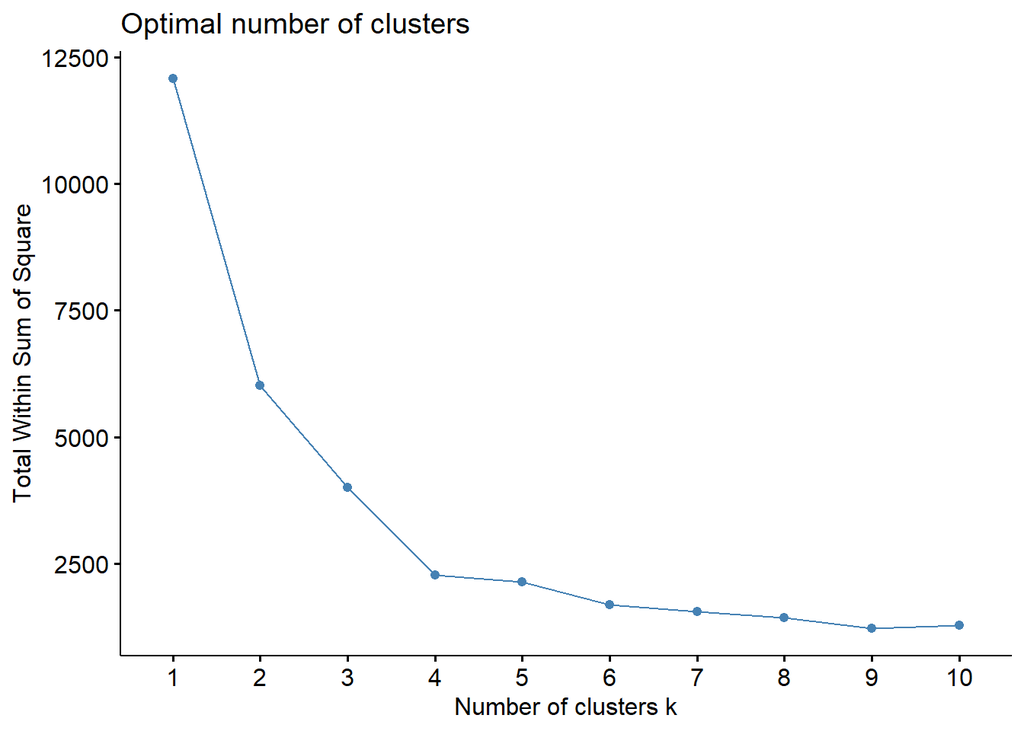

```r
# https://stackoverflow.com/a/53751880
fviz_nbclust(
  x = df,
  FUNcluster = kmeans,
  method = "wss",
  k.max = 10,
  diss = dist(df, method = "manhattan")
)
```

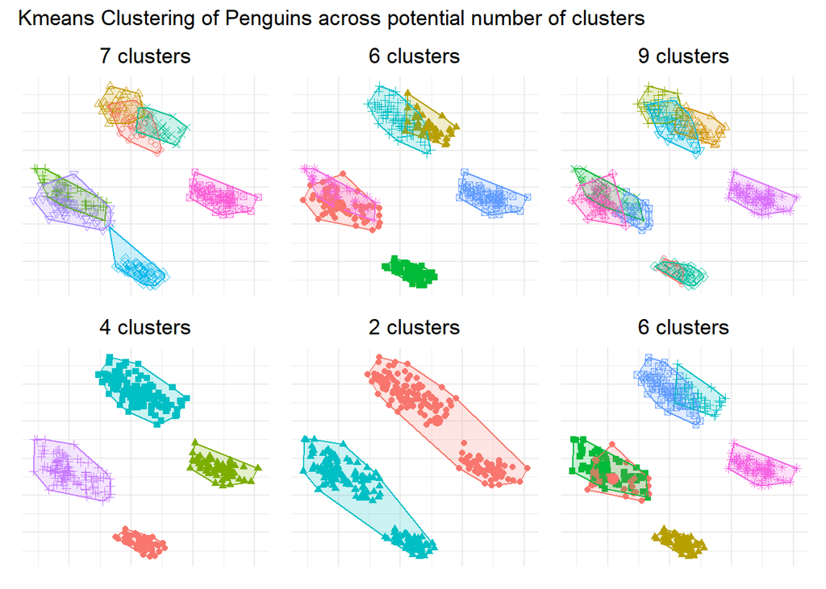

```r
cluster_sample <- kmeans_metrics |>
  slice_sample(n = 6, replace = FALSE)

plots <- pmap(
  cluster_sample,
  function(num_clusters, nstart, silhouette) {
    display_cluster(num_clusters, kmeans(df, num_clusters, nstart = nstart), df)
  }
)

reduce(plots, `+`) +
  plot_annotation(
    title = "Kmeans Clustering of Penguins across potential number of clusters",
  )
```

```r
(best_result <- kmeans_metrics[which.max(kmeans_metrics$silhouette), ])
```

```
## # A tibble: 1 × 3
##   num_clusters nstart silhouette
##          <int>  <dbl>      <dbl>
## 1            4      5       154.
```

```r
display_cluster(
  best_result$num_clusters,
  kmeans(df, best_result$num_clusters, nstart = best_result$nstart),
  df
)
```

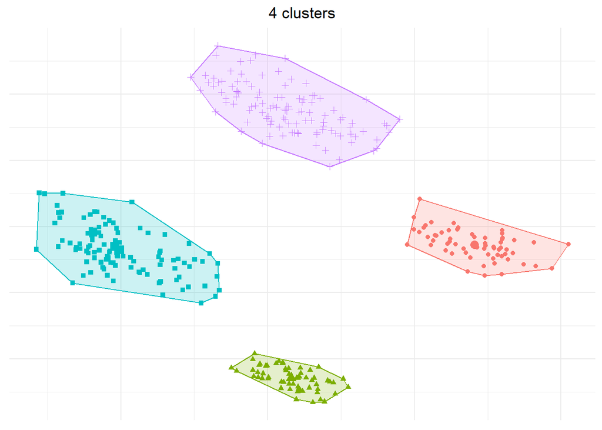

After conducting an exhaustive search of parameter combinations, we have concluded that 4 clusters is the optimal grouping for our data.

#### Partitioning Around Medoids (PAM)

We will perform the k-medoids function on our dataset, and within the function, we will once again use different parameters in order to seek improved results.

```r
perform_pam <- function(data, n_clusters) {
  cluster_data <- pam(data, n_clusters)
  return(list(
    num_clusters = n_clusters,
    silhouette = sum(data.frame(silhouette(cluster_data, dist(data)))$sil_width)
  ))
}
```

```r
pam_metrics <- bind_rows(
  map(2:6, function(x) perform_pam(df, x))
)

head(pam_metrics, n = 5)
```

```
## # A tibble: 5 × 2
##   num_clusters silhouette
##          <int>      <dbl>
## 1            2       120.
## 2            3       127.
## 3            4       154.
## 4            5       137.
## 5            6       133.
```

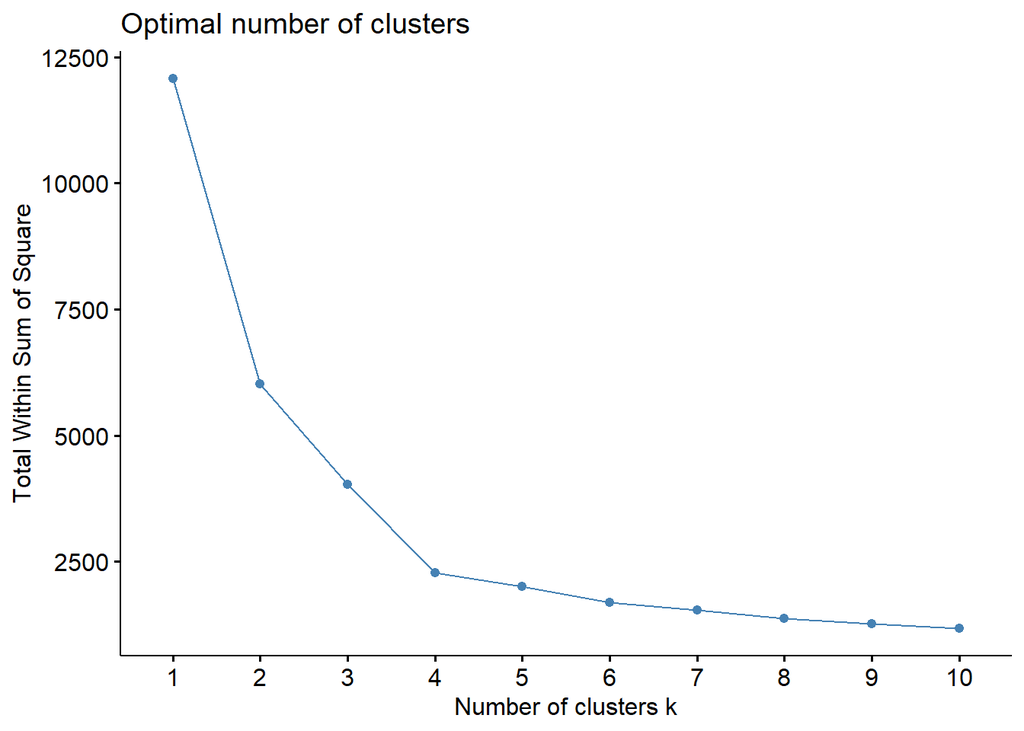

```r
fviz_nbclust(
  x = df,
  FUNcluster = pam,
  method = "wss",
  k.max = 10,
  diss = dist(df, method = "manhattan")
)
```

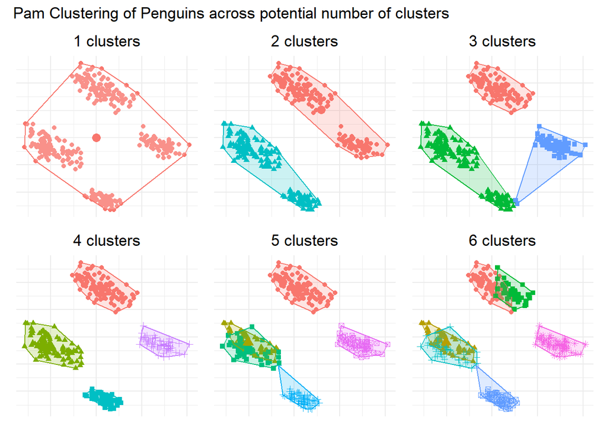

```r
plots <- map(
  1:6,
  function(x) {
    display_cluster(
      x,
      pam(df, x),
      df
    )
  }
)

reduce(plots, `+`) +
  plot_annotation(
    title = "Pam Clustering of Penguins across potential number of clusters",
  )
```

```r
(best_result <- pam_metrics[which.max(pam_metrics$silhouette), ])
```

```
## # A tibble: 1 × 2
##   num_clusters silhouette
##          <int>      <dbl>
## 1            4       154.
```

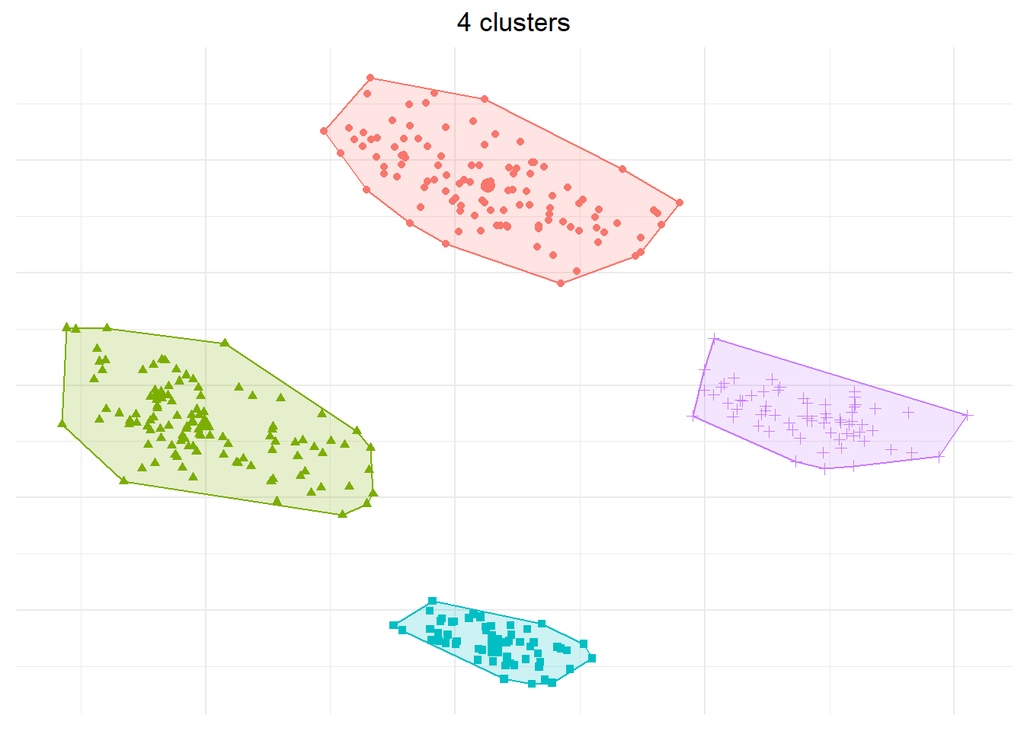

```r
display_cluster(best_result$num_clusters, pam(df, best_result$num_clusters), df)
```

We observe that with this algorithm, we continue to see that 4 clusters are the ones that best adapt to our data.

#### DBSCAN

```r
perform_dbscan <- function(eps, min_pts, data) {
  dbscan_result <- dbscan(data, eps = eps, minPts = min_pts)
  return(list(
    eps = eps,
    minPts = min_pts,
    silhouette = sum(
      data.frame(silhouette(dbscan_result$cluster, dist(data)))$sil_width
    ),
    num_clusters = length(unique(dbscan_result$cluster)) - 1
  ))
}
```

```r
param_combinations <- expand.grid(
  eps = seq(0.1, 2, 0.1),
  min_pts = 1:10
)

dbscan_metrics <- bind_rows(
  pmap(param_combinations, ~ perform_dbscan(..1, ..2, df))
)

head(dbscan_metrics, n = 5)
```

```
## # A tibble: 5 × 4
##     eps minPts silhouette num_clusters
##   <dbl>  <int>      <dbl>        <dbl>
## 1   0.1      1       0             343
## 2   0.2      1       9.96          333
## 3   0.3      1      31.6           297
## 4   0.4      1      45.1           226
## 5   0.5      1      31.2           154
```

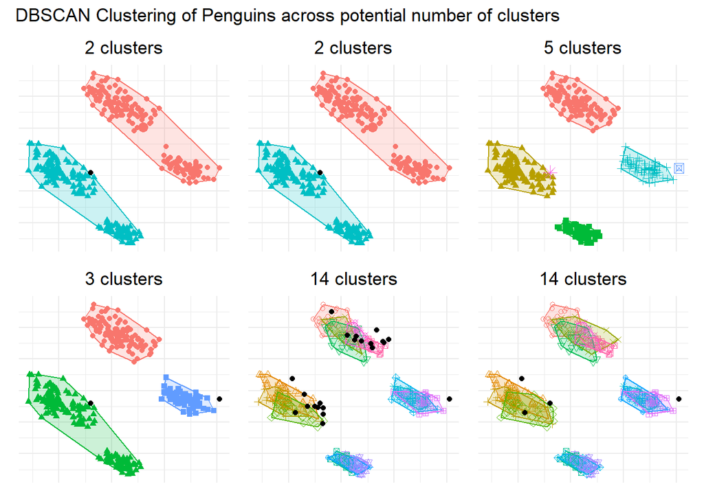

```r
cluster_sample <- dbscan_metrics |>
  slice_sample(n = 6, replace = FALSE)

plots <- pmap(
  cluster_sample,
  function(eps, minPts, silhouette, num_clusters) {
    display_cluster(num_clusters, dbscan(df, eps = eps, minPts = minPts), df)
  }
)

reduce(plots, `+`) +
  plot_annotation(
    title = "DBSCAN Clustering of Penguins across potential number of clusters",
  )
```

```r
(best_result <- dbscan_metrics[which.max(dbscan_metrics$silhouette), ])
```

```
## # A tibble: 1 × 4
##     eps minPts silhouette num_clusters
##   <dbl>  <int>      <dbl>        <dbl>
## 1   1.4      2       153.            4
```

```r
display_cluster(
  best_result$num_clusters,
  dbscan(df, best_result$eps, best_result$minPts),
  df
)
```

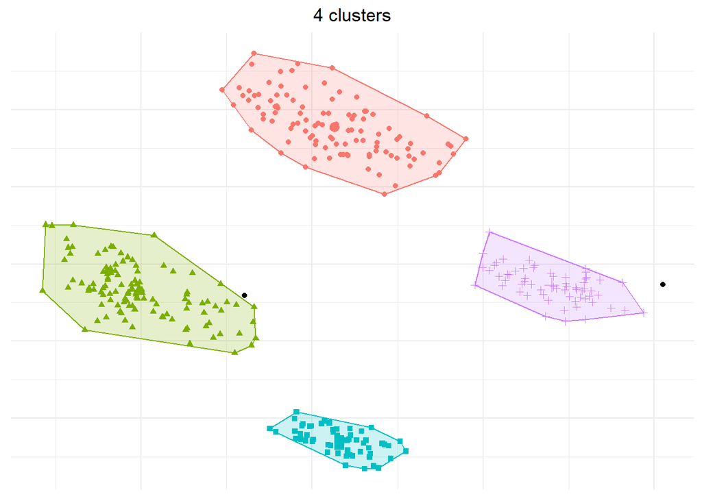

With the DBSCAN method, we once again find that 4 clusters are the number that best fits our data. As an additional insight, with this algorithm, we can also observe that there are two points considered as noise, meaning they do not belong to any cluster. This adds to the robustness of the model compared to the two previously used methods

### Hierarchical

#### Hclust

We performed an agglomerative hierarchical clustering of the data and assessed its performance based on the silhouette.

```r
perform_hclust <- function(data, method, num_clusters) {
  hc <- hclust(dist(data), method = method)
  hc <- cutree(hc, k = num_clusters)
  return(list(
    method = method,
    num_clusters = num_clusters,
    silhouette = sum(data.frame(silhouette(hc, dist(data)))$sil_width)
  ))
}

plot_hclust <- function(data, method, num_clusters) {
  hc <- as.dendrogram(hclust(dist(data), method = method))
  hc <- color_branches(hc, k = num_clusters)
  labels(hc) <- NULL

  # Customize the ggplot dendrogram
  fviz_dend(
    hc,
    main = glue("Clusters: {num_clusters}\nMethod: {method}"),
    show_labels = FALSE
  ) +
    theme( # nolint
      plot.title = element_text(size = 14, hjust = 0.5), # nolint
    )
}
```

We will perform hierarchical analysis with various combinations of parameters and save the compiled metrics for comparison. We will use this analysis with different methods: “single”, “complete”, “average”, “mcquitty”, “median”, “centroid”. `ward.D` and `ward.D2`, though yielding the best results (only 1 point better), were excluded from the study as their cluster data resulted in very difficult to comprehend plots

```r
parameters <- expand.grid(
  method = c(
    # "ward.D", "ward.D2",
    "single", "complete", "average", "mcquitty", "median", "centroid"
  ),
  num_clusters = 2:10
)

hclust_metrics <- bind_rows(
  pmap(parameters, ~ perform_hclust(df, ..1, ..2))
)

head(hclust_metrics, n = 5)
```

```
## # A tibble: 5 × 3
##   method   num_clusters silhouette
##   <fct>           <int>      <dbl>
## 1 single              2      120.
## 2 complete            2       99.6
## 3 average             2      120.
## 4 mcquitty            2       99.6
## 5 median              2       59.9
```

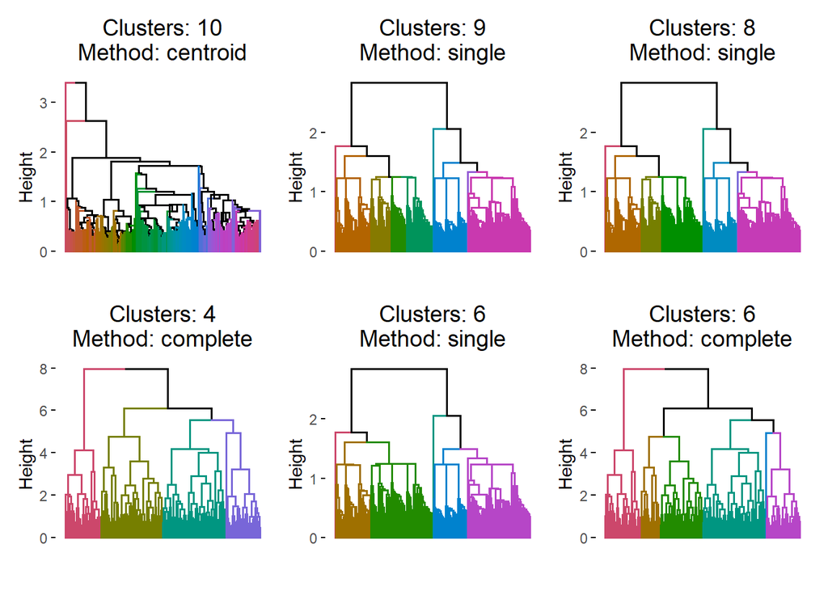

```r
cluster_sample <- hclust_metrics |>
  slice_sample(n = 6, replace = FALSE) |>
  mutate(method = as.character(method))

# Apply the function to each row of the tibble
plots <- pmap(
  cluster_sample,
  function(method, num_clusters, silhouette) plot_hclust(df, method, num_clusters)
)

reduce(plots, `+`)
```

```r
(best_result <- hclust_metrics[which.max(hclust_metrics$silhouette), ])
```

```
## # A tibble: 1 × 3
##   method   num_clusters silhouette
##   <fct>           <int>      <dbl>
## 1 complete            4       153.
```

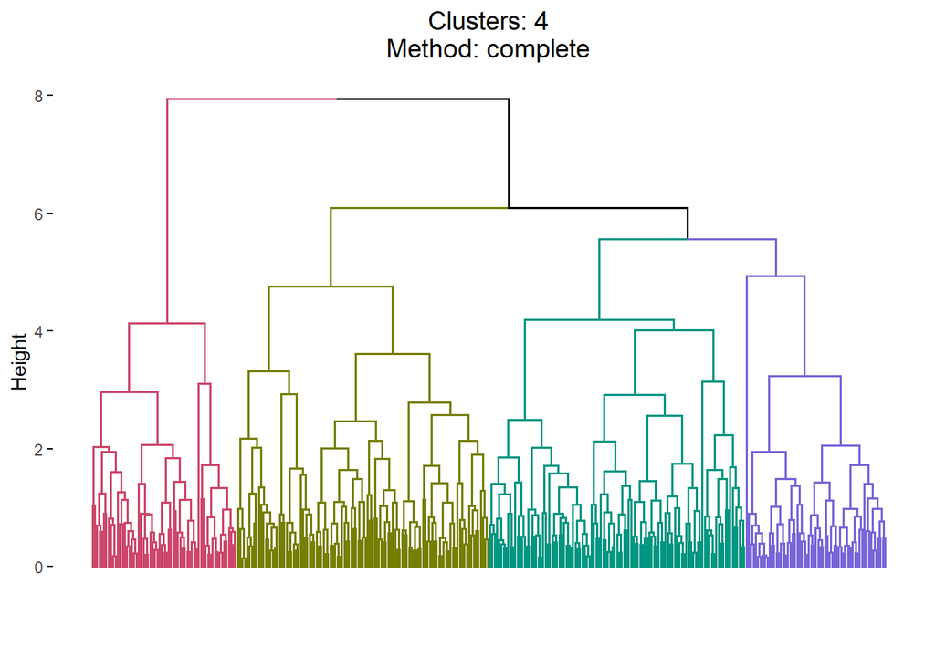

```r
plot_hclust(df, best_result$method, best_result$num_clusters)
```

Based on the analysis of metrics, we can conclude that with the hierarchical algorithm, the best number of clusters obtained is 4, using the complete method.

#### Agnes

We perform hierarchical analysis with the Agglomerative Nesting algorithm (agnes), and we will evaluate the performance using the silhouette metric once again. We will conduct this analysis with different methods: ‘average,’ ‘single,’ ‘complete,’ ‘weighted,’ and with the number of clusters ranging from 2 to 10

```r
perform_agnes <- function(data, method, num_clusters) {
  hc <- agnes(data, method = method)
  hc <- cutree(hc, k = num_clusters)
  return(list(
    method = method,
    num_clusters = num_clusters,
    silhouette = sum(data.frame(silhouette(hc, dist(data)))$sil_width)
  ))
}

plot_agnes <- function(data, method, num_clusters) {
  hc <- as.dendrogram(agnes(dist(data), method = method))
  hc <- color_branches(hc, k = num_clusters)

  # Customize the ggplot dendrogram
  fviz_dend(
    hc,
    main = glue("Clusters: {num_clusters}\nMethod: {method}"),
    show_labels = FALSE
  ) +
    theme( # nolint
      plot.title = element_text(size = 14, hjust = 0.5), # nolint
    )
}
```

```r
parameters <- expand.grid(
  method = c(
    "average", "single", "complete", "weighted"
  ),
  num_clusters = 2:10
)

agnes_metrics <- bind_rows(
  pmap(parameters, ~ perform_agnes(df, ..1, ..2))
)

head(agnes_metrics, n = 5)
```

```
## # A tibble: 5 × 3
##   method   num_clusters silhouette
##   <fct>           <int>      <dbl>
## 1 average             2      120.
## 2 single              2      120.
## 3 complete            2       99.6
## 4 weighted            2       99.6
## 5 average             3      103.
```

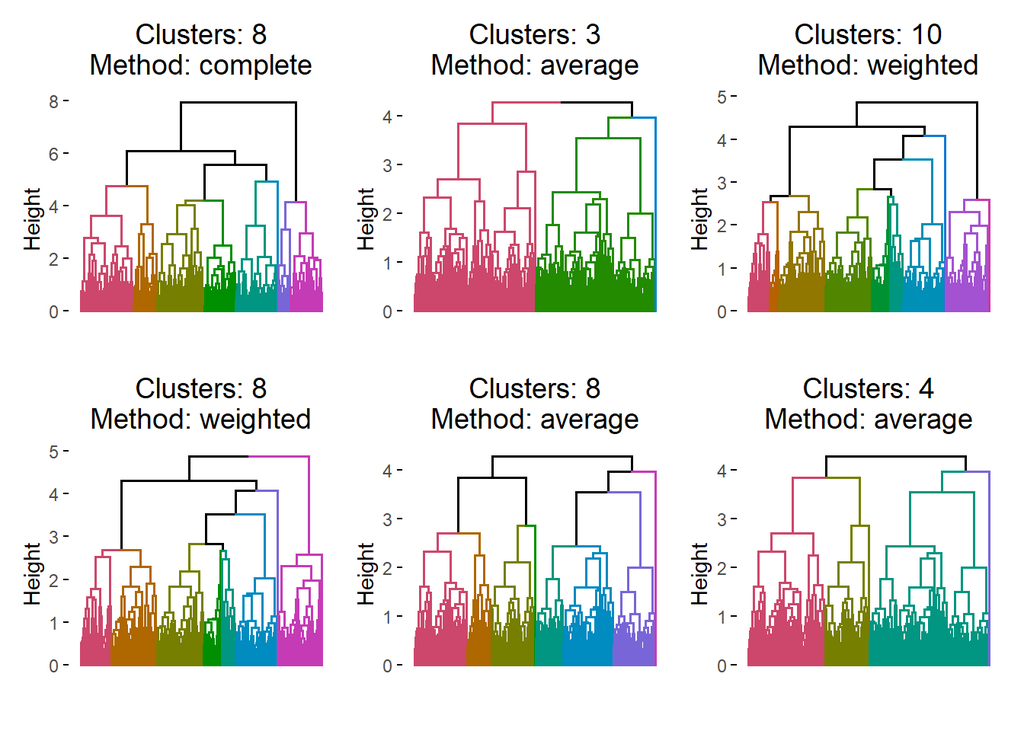

```r
cluster_sample <- agnes_metrics |>
  slice_sample(n = 6, replace = FALSE) |>
  mutate(method = as.character(method))

plots <- pmap(
  cluster_sample,
  function(method, num_clusters, silhouette) plot_agnes(df, method, num_clusters)
)

reduce(plots, `+`)
```

```r
(best_result <- agnes_metrics[which.max(agnes_metrics$silhouette), ])
```

```
## # A tibble: 1 × 3
##   method   num_clusters silhouette
##   <fct>           <int>      <dbl>
## 1 complete            4       153.
```

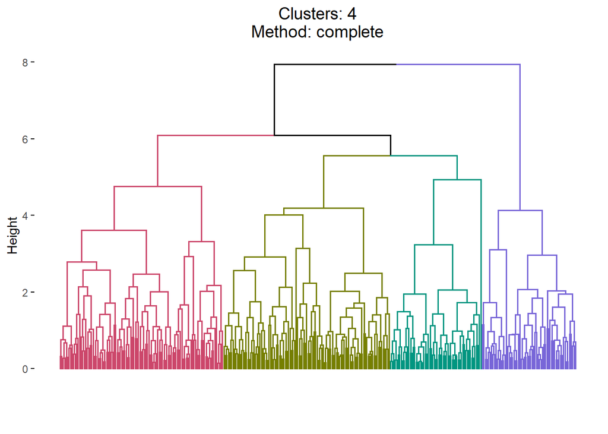

```r
plot_agnes(df, best_result$method, best_result$num_clusters)
```

With the agnes method, we can observe a result similar to hclust, with the best outcome being 4 clusters using the complete method. However, the way the data is agglomerated is inverse, this could be because the agnes method focuses on agglomerative nesting, meaning that it first joins the most similar objects and then groups those clusters into larger clusters. In this case, we can see how it joins the last cluster at the end of the dendrogram, whereas in hclust, the one that joined last was the first.

#### Diana

As the last algorithm, we will use DIANA, DIvisive ANAlysis. We will also use different parameters, such as metrics: “Euclidean” and “Manhattan”, and a number of clusters ranging from 2 to 10.

With this method, we focus on taking a large group and progressively dividing it into smaller subgroups, which is contrary to the previous methods where we focused on combining smaller clusters to obtain larger ones.

```r
perform_diana <- function(data, metric, num_clusters) {
  hc <- diana(data, metric = metric)
  hc <- cutree(hc, k = num_clusters)
  return(list(
    metric = metric,
    num_clusters = num_clusters,
    silhouette = sum(data.frame(silhouette(hc, dist(data)))$sil_width)
  ))
}

plot_diana <- function(data, metric, num_clusters) {
  hc <- as.dendrogram(diana(data, metric = metric))
  hc <- color_branches(hc, k = num_clusters)

  # Customize the ggplot dendrogram
  fviz_dend(
    hc,
    main = glue("Clusters: {num_clusters}\nMetric: {metric}"),
    show_labels = FALSE
  ) +
    theme( # nolint
      plot.title = element_text(size = 14, hjust = 0.5), # nolint
    )
}
```

```r
parameters <- expand.grid(
  metric = c("euclidean", "manhattan"),
  num_clusters = 2:10
)

diana_metrics <- bind_rows(
  pmap(parameters, ~ perform_diana(df, ..1, ..2))
)

head(diana_metrics, n = 5)
```

```
## # A tibble: 5 × 3
##   metric    num_clusters silhouette
##   <fct>            <int>      <dbl>
## 1 euclidean            2       120.
## 2 manhattan            2       120.
## 3 euclidean            3       128.
## 4 manhattan            3       128.
## 5 euclidean            4       135.
```

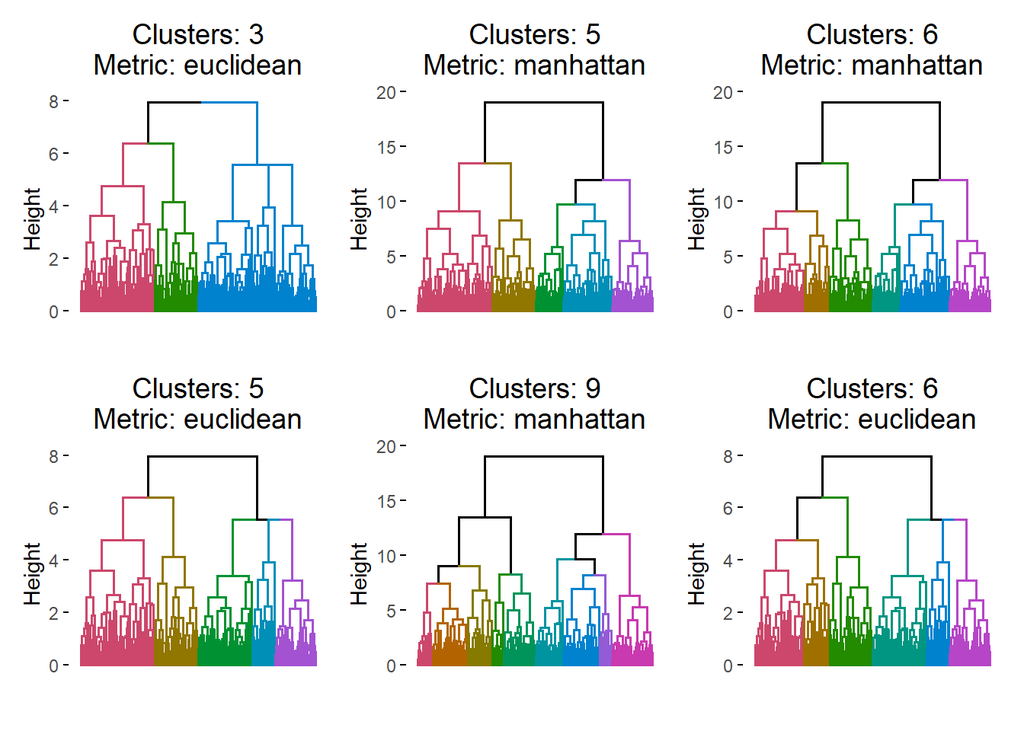

```r
cluster_sample <- diana_metrics |>
  slice_sample(n = 6, replace = FALSE) |>
  mutate(metric = as.character(metric))

plots <- pmap(
  cluster_sample,
  function(metric, num_clusters, silhouette) plot_diana(df, metric, num_clusters)
)

reduce(plots, `+`)
```

```r
(best_result <- diana_metrics[which.max(diana_metrics$silhouette), ])
```

```
## # A tibble: 1 × 3
##   metric    num_clusters silhouette
##   <fct>            <int>      <dbl>
## 1 manhattan            4       154.
```

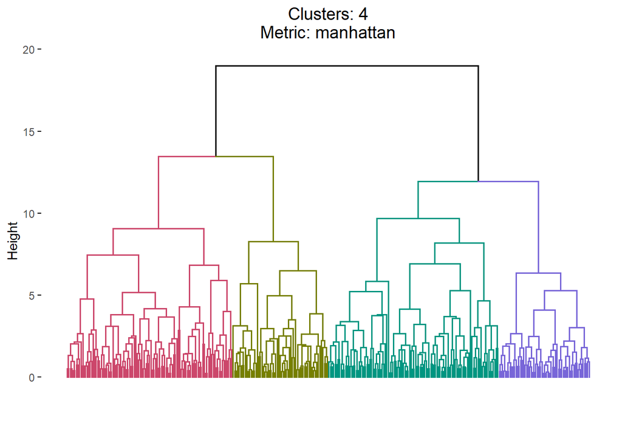

```r
plot_diana(df, best_result$metric, best_result$num_clusters)
```

Once again, we find that the optimal number of clusters is 4. This result has been consistent throughout the entire study, and in this particular case, the metric used was Manhattan.

## Conclusion

For the resolution of the assessment, we had to start by cleaning the dataset to understand its content and structure. We began by removing variables that did not contribute information. Checking the presence of non numeric values, we found non numeric values in the `sex` attribute. We faced the dilemma of how to handle it; Since it was of type `chr`, direct replacement with the mean or median was not possible. Therefore, we decided to apply data balancing and use one-hot encoding to address this issue. For the subsequent attributes with non numeric values that were of numeric type, we simply replaced them with the mean of the respective attributes. Finally, we normalize the data, thus concluding the processing and cleaning of the dataset.

To perform clustering, we followed a framework in which we implemented the clustering function for all types. We also created helper functions to perform each clustering multiple times with different parameters, aiming to make each model as well-fitted as possible. Finally, we displayed several executions for comparison and showcased the best result obtained from each clustering.

As a conclusion of the study, we observe that the most suitable choice for this dataset is to create 4 clusters. This deduction arises from the fact that, across all the metric combinations we have tested for all models, 4 clusters has consistently yielded the best result.